# Risk Factor Analysis

## Outcome Variable

**Outcome Variable:** stunted

## Predictor Variables

**Intervention Variable:** feducyrs

**Adjustment Set:**

unadjusted

## Stratifying Variables

The analysis was stratified on these variable(s):

- agecat
- studyid
- country

## Data Summary

| agecat | studyid | country | feducyrs | stunted | n_cell | n |
| --- | --- | --- | --- | --- | --- | --- |
| Birth | ki0047075b-MAL-ED | BANGLADESH | Q4 | 0 | 44 | 144 |
| Birth | ki0047075b-MAL-ED | BANGLADESH | Q4 | 1 | 8 | 144 |
| Birth | ki0047075b-MAL-ED | BANGLADESH | Q1 | 0 | 24 | 144 |
| Birth | ki0047075b-MAL-ED | BANGLADESH | Q1 | 1 | 5 | 144 |
| Birth | ki0047075b-MAL-ED | BANGLADESH | Q2 | 0 | 6 | 144 |
| Birth | ki0047075b-MAL-ED | BANGLADESH | Q2 | 1 | 3 | 144 |
| Birth | ki0047075b-MAL-ED | BANGLADESH | Q3 | 0 | 44 | 144 |
| Birth | ki0047075b-MAL-ED | BANGLADESH | Q3 | 1 | 10 | 144 |
| 6 months | ki0047075b-MAL-ED | BANGLADESH | Q4 | 0 | 44 | 132 |
| 6 months | ki0047075b-MAL-ED | BANGLADESH | Q4 | 1 | 6 | 132 |
| 6 months | ki0047075b-MAL-ED | BANGLADESH | Q1 | 0 | 24 | 132 |
| 6 months | ki0047075b-MAL-ED | BANGLADESH | Q1 | 1 | 5 | 132 |
| 6 months | ki0047075b-MAL-ED | BANGLADESH | Q2 | 0 | 5 | 132 |
| 6 months | ki0047075b-MAL-ED | BANGLADESH | Q2 | 1 | 2 | 132 |
| 6 months | ki0047075b-MAL-ED | BANGLADESH | Q3 | 0 | 39 | 132 |
| 6 months | ki0047075b-MAL-ED | BANGLADESH | Q3 | 1 | 7 | 132 |
| 24 months | ki0047075b-MAL-ED | BANGLADESH | Q4 | 0 | 28 | 117 |
| 24 months | ki0047075b-MAL-ED | BANGLADESH | Q4 | 1 | 12 | 117 |
| 24 months | ki0047075b-MAL-ED | BANGLADESH | Q1 | 0 | 17 | 117 |
| 24 months | ki0047075b-MAL-ED | BANGLADESH | Q1 | 1 | 12 | 117 |
| 24 months | ki0047075b-MAL-ED | BANGLADESH | Q2 | 0 | 4 | 117 |
| 24 months | ki0047075b-MAL-ED | BANGLADESH | Q2 | 1 | 2 | 117 |
| 24 months | ki0047075b-MAL-ED | BANGLADESH | Q3 | 0 | 20 | 117 |
| 24 months | ki0047075b-MAL-ED | BANGLADESH | Q3 | 1 | 22 | 117 |
| Birth | ki0047075b-MAL-ED | INDIA | Q4 | 0 | 32 | 123 |
| Birth | ki0047075b-MAL-ED | INDIA | Q4 | 1 | 6 | 123 |
| Birth | ki0047075b-MAL-ED | INDIA | Q1 | 0 | 20 | 123 |
| Birth | ki0047075b-MAL-ED | INDIA | Q1 | 1 | 1 | 123 |
| Birth | ki0047075b-MAL-ED | INDIA | Q2 | 0 | 33 | 123 |
| Birth | ki0047075b-MAL-ED | INDIA | Q2 | 1 | 4 | 123 |

[output cut: 388 more lines]

The following strata were considered:

- agecat: 24 months, studyid: ki0047075b-MAL-ED, country: BANGLADESH
- agecat: 24 months, studyid: ki0047075b-MAL-ED, country: INDIA
- agecat: 24 months, studyid: ki0047075b-MAL-ED, country: NEPAL
- agecat: 24 months, studyid: ki0047075b-MAL-ED, country: PERU
- agecat: 24 months, studyid: ki0047075b-MAL-ED, country: SOUTH AFRICA
- agecat: 24 months, studyid: ki0047075b-MAL-ED, country: TANZANIA, UNITED REPUBLIC OF
- agecat: 24 months, studyid: ki1017093b-PROVIDE, country: BANGLADESH
- agecat: 24 months, studyid: ki1017093c-NIH-Crypto, country: BANGLADESH
- agecat: 24 months, studyid: ki1066203-TanzaniaChild2, country: TANZANIA, UNITED REPUBLIC OF
- agecat: 24 months, studyid: ki1113344-GMS-Nepal, country: NEPAL
- agecat: 24 months, studyid: ki1119695-PROBIT, country: BELARUS
- agecat: 24 months, studyid: ki1126311-ZVITAMBO, country: ZIMBABWE
- agecat: 24 months, studyid: ki1135781-COHORTS, country: GUATEMALA
- agecat: 24 months, studyid: ki1135781-COHORTS, country: INDIA
- agecat: 24 months, studyid: ki1135781-COHORTS, country: PHILIPPINES
- agecat: 24 months, studyid: ki1148112-LCNI-5, country: MALAWI
- agecat: 24 months, studyid: kiGH5241-JiVitA-3, country: BANGLADESH
- agecat: 24 months, studyid: kiGH5241-JiVitA-4, country: BANGLADESH
- agecat: 6 months, studyid: ki0047075b-MAL-ED, country: BANGLADESH
- agecat: 6 months, studyid: ki0047075b-MAL-ED, country: INDIA
- agecat: 6 months, studyid: ki0047075b-MAL-ED, country: NEPAL
- agecat: 6 months, studyid: ki0047075b-MAL-ED, country: PERU
- agecat: 6 months, studyid: ki0047075b-MAL-ED, country: SOUTH AFRICA
- agecat: 6 months, studyid: ki0047075b-MAL-ED, country: TANZANIA, UNITED REPUBLIC OF
- agecat: 6 months, studyid: ki1000304b-SAS-CompFeed, country: INDIA
- agecat: 6 months, studyid: ki1000304b-SAS-FoodSuppl, country: INDIA
- agecat: 6 months, studyid: ki1017093b-PROVIDE, country: BANGLADESH
- agecat: 6 months, studyid: ki1017093c-NIH-Crypto, country: BANGLADESH
- agecat: 6 months, studyid: ki1066203-TanzaniaChild2, country: TANZANIA, UNITED REPUBLIC OF
- agecat: 6 months, studyid: ki1113344-GMS-Nepal, country: NEPAL
- agecat: 6 months, studyid: ki1119695-PROBIT, country: BELARUS
- agecat: 6 months, studyid: ki1126311-ZVITAMBO, country: ZIMBABWE
- agecat: 6 months, studyid: ki1135781-COHORTS, country: GUATEMALA
- agecat: 6 months, studyid: ki1135781-COHORTS, country: INDIA
- agecat: 6 months, studyid: ki1135781-COHORTS, country: PHILIPPINES
- agecat: 6 months, studyid: ki1148112-LCNI-5, country: MALAWI
- agecat: 6 months, studyid: kiGH5241-JiVitA-3, country: BANGLADESH
- agecat: 6 months, studyid: kiGH5241-JiVitA-4, country: BANGLADESH
- agecat: Birth, studyid: ki0047075b-MAL-ED, country: BANGLADESH
- agecat: Birth, studyid: ki0047075b-MAL-ED, country: INDIA
- agecat: Birth, studyid: ki0047075b-MAL-ED, country: NEPAL
- agecat: Birth, studyid: ki0047075b-MAL-ED, country: PERU
- agecat: Birth, studyid: ki0047075b-MAL-ED, country: SOUTH AFRICA
- agecat: Birth, studyid: ki0047075b-MAL-ED, country: TANZANIA, UNITED REPUBLIC OF
- agecat: Birth, studyid: ki1000304b-SAS-CompFeed, country: INDIA
- agecat: Birth, studyid: ki1017093c-NIH-Crypto, country: BANGLADESH
- agecat: Birth, studyid: ki1119695-PROBIT, country: BELARUS
- agecat: Birth, studyid: ki1126311-ZVITAMBO, country: ZIMBABWE
- agecat: Birth, studyid: ki1135781-COHORTS, country: GUATEMALA
- agecat: Birth, studyid: ki1135781-COHORTS, country: INDIA
- agecat: Birth, studyid: ki1135781-COHORTS, country: PHILIPPINES
- agecat: Birth, studyid: kiGH5241-JiVitA-3, country: BANGLADESH
- agecat: Birth, studyid: kiGH5241-JiVitA-4, country: BANGLADESH

### Dropped Strata

Some strata were dropped due to rare outcomes:

- agecat: Birth, studyid: ki0047075b-MAL-ED, country: BANGLADESH
- agecat: 6 months, studyid: ki0047075b-MAL-ED, country: BANGLADESH
- agecat: 24 months, studyid: ki0047075b-MAL-ED, country: BANGLADESH
- agecat: Birth, studyid: ki0047075b-MAL-ED, country: INDIA
- agecat: 6 months, studyid: ki0047075b-MAL-ED, country: INDIA
- agecat: 6 months, studyid: ki0047075b-MAL-ED, country: NEPAL
- agecat: 24 months, studyid: ki0047075b-MAL-ED, country: NEPAL
- agecat: Birth, studyid: ki0047075b-MAL-ED, country: NEPAL
- agecat: Birth, studyid: ki0047075b-MAL-ED, country: PERU
- agecat: 6 months, studyid: ki0047075b-MAL-ED, country: PERU
- agecat: 24 months, studyid: ki0047075b-MAL-ED, country: PERU
- agecat: Birth, studyid: ki0047075b-MAL-ED, country: SOUTH AFRICA
- agecat: 6 months, studyid: ki0047075b-MAL-ED, country: SOUTH AFRICA
- agecat: Birth, studyid: ki0047075b-MAL-ED, country: TANZANIA, UNITED REPUBLIC OF
- agecat: 6 months, studyid: ki0047075b-MAL-ED, country: TANZANIA, UNITED REPUBLIC OF
- agecat: 24 months, studyid: ki0047075b-MAL-ED, country: TANZANIA, UNITED REPUBLIC OF
- agecat: Birth, studyid: ki1000304b-SAS-CompFeed, country: INDIA
- agecat: 6 months, studyid: ki1017093b-PROVIDE, country: BANGLADESH
- agecat: 24 months, studyid: ki1017093b-PROVIDE, country: BANGLADESH
- agecat: Birth, studyid: ki1017093c-NIH-Crypto, country: BANGLADESH
- agecat: 6 months, studyid: ki1066203-TanzaniaChild2, country: TANZANIA, UNITED REPUBLIC OF
- agecat: 24 months, studyid: ki1066203-TanzaniaChild2, country: TANZANIA, UNITED REPUBLIC OF
- agecat: Birth, studyid: ki1119695-PROBIT, country: BELARUS
- agecat: 24 months, studyid: ki1119695-PROBIT, country: BELARUS
- agecat: 24 months, studyid: ki1126311-ZVITAMBO, country: ZIMBABWE
- agecat: 6 months, studyid: ki1135781-COHORTS, country: GUATEMALA
- agecat: 24 months, studyid: ki1135781-COHORTS, country: GUATEMALA
- agecat: Birth, studyid: ki1135781-COHORTS, country: GUATEMALA
- agecat: 6 months, studyid: kiGH5241-JiVitA-4, country: BANGLADESH
- agecat: Birth, studyid: kiGH5241-JiVitA-4, country: BANGLADESH

## Methods Detail

We’re interested in the causal parameters $E[Y_a]$ for all values of $a \in \mathcal{A}$. These parameters represent the mean outcome if, possibly contrary to fact, we intervened to set all units to have $A=a$. Under the randomization and positivity assumptions, these are identified by the statistical parameters $\psi_a=E_W[E_{Y|A,W}(Y|A=a,W)]$. In addition, we’re interested in the mean of $Y$, $E[Y]$ under no intervention (the observed mean). We will estimate these parameters by using SuperLearner to fit the relevant likelihood factors – $E_{Y|A,W}(Y|A=a,W)$ and $p(A=a|W)$, and then updating our likelihood fit using a joint TMLE.

For unadjusted analyses ($W=\{\}$), initial likelihoods were estimated using Lrnr_glm to estimate the simple $E(Y|A)$ and Lrnr_mean to estimate $p(A)$. For adjusted analyses, a small library containing Lrnr_glmnet, Lrnr_xgboost, and Lrnr_mean was used.

Having estimated these parameters, we will then use the delta method to estimate relative risks and attributable risks relative to a prespecified baseline level of $A$.

# Results Detail

## Results Plots

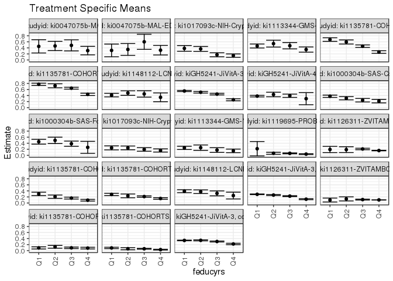

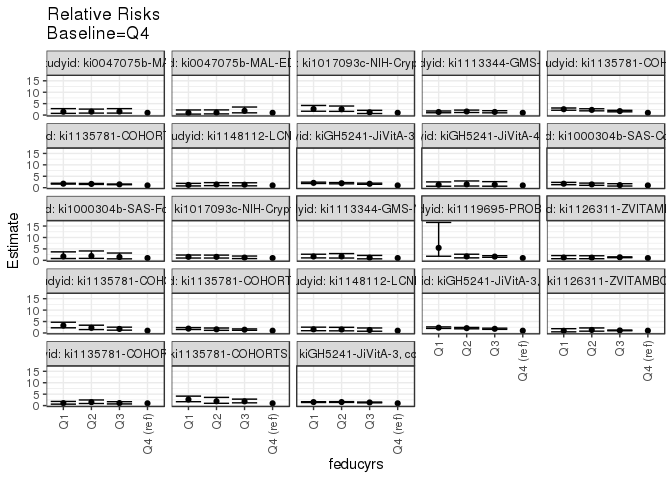

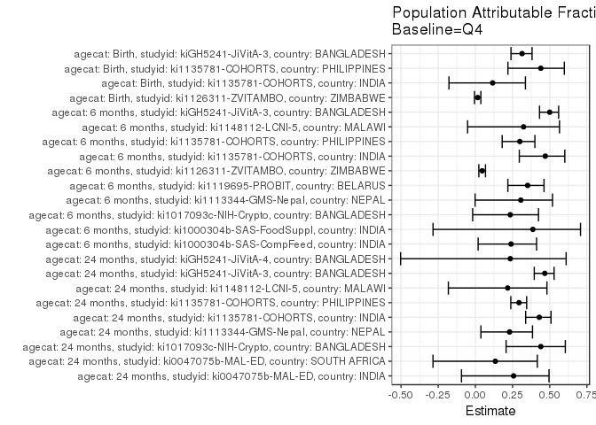

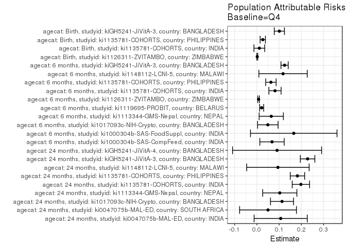

## Results Table

### Parameter: TSM

| agecat | studyid | country | intervention_level | baseline_level | estimate | ci_lower | ci_upper |
| --- | --- | --- | --- | --- | --- | --- | --- |
| Birth | ki1126311-ZVITAMBO | ZIMBABWE | Q4 | NA | 0.1013561 | 0.0958409 | 0.1068712 |
| Birth | ki1126311-ZVITAMBO | ZIMBABWE | Q1 | NA | 0.0975610 | 0.0333360 | 0.1617860 |
| Birth | ki1126311-ZVITAMBO | ZIMBABWE | Q2 | NA | 0.1340206 | 0.0662225 | 0.2018188 |
| Birth | ki1126311-ZVITAMBO | ZIMBABWE | Q3 | NA | 0.1119865 | 0.0973238 | 0.1266492 |
| Birth | ki1135781-COHORTS | INDIA | Q4 | NA | 0.0842105 | 0.0562788 | 0.1121423 |
| Birth | ki1135781-COHORTS | INDIA | Q1 | NA | 0.0909091 | 0.0546758 | 0.1271424 |
| Birth | ki1135781-COHORTS | INDIA | Q2 | NA | 0.1269036 | 0.0804046 | 0.1734025 |
| Birth | ki1135781-COHORTS | INDIA | Q3 | NA | 0.0934579 | 0.0687843 | 0.1181316 |
| Birth | ki1135781-COHORTS | PHILIPPINES | Q4 | NA | 0.0337349 | 0.0214500 | 0.0460199 |
| Birth | ki1135781-COHORTS | PHILIPPINES | Q1 | NA | 0.0898876 | 0.0674242 | 0.1123511 |
| Birth | ki1135781-COHORTS | PHILIPPINES | Q2 | NA | 0.0637255 | 0.0302006 | 0.0972503 |
| Birth | ki1135781-COHORTS | PHILIPPINES | Q3 | NA | 0.0625000 | 0.0488924 | 0.0761076 |
| Birth | kiGH5241-JiVitA-3 | BANGLADESH | Q4 | NA | 0.2208054 | 0.1973568 | 0.2442539 |
| Birth | kiGH5241-JiVitA-3 | BANGLADESH | Q1 | NA | 0.3377930 | 0.3277891 | 0.3477969 |
| Birth | kiGH5241-JiVitA-3 | BANGLADESH | Q2 | NA | 0.3405269 | 0.3235513 | 0.3575025 |
| Birth | kiGH5241-JiVitA-3 | BANGLADESH | Q3 | NA | 0.3025362 | 0.2865720 | 0.3185005 |
| 6 months | ki1000304b-SAS-CompFeed | INDIA | Q4 | NA | 0.2155172 | 0.1572413 | 0.2737932 |
| 6 months | ki1000304b-SAS-CompFeed | INDIA | Q1 | NA | 0.3758389 | 0.3373352 | 0.4143427 |
| 6 months | ki1000304b-SAS-CompFeed | INDIA | Q2 | NA | 0.3115727 | 0.2577831 | 0.3653623 |
| 6 months | ki1000304b-SAS-CompFeed | INDIA | Q3 | NA | 0.2457143 | 0.1878494 | 0.3035792 |
| 6 months | ki1000304b-SAS-FoodSuppl | INDIA | Q4 | NA | 0.2631579 | 0.0648962 | 0.4614196 |
| 6 months | ki1000304b-SAS-FoodSuppl | INDIA | Q1 | NA | 0.4496644 | 0.3696837 | 0.5296451 |
| 6 months | ki1000304b-SAS-FoodSuppl | INDIA | Q2 | NA | 0.4942529 | 0.3890562 | 0.5994495 |
| 6 months | ki1000304b-SAS-FoodSuppl | INDIA | Q3 | NA | 0.3840000 | 0.2986269 | 0.4693731 |
| 6 months | ki1017093c-NIH-Crypto | BANGLADESH | Q4 | NA | 0.1606218 | 0.1087830 | 0.2124605 |
| 6 months | ki1017093c-NIH-Crypto | BANGLADESH | Q1 | NA | 0.2453988 | 0.1792909 | 0.3115066 |
| 6 months | ki1017093c-NIH-Crypto | BANGLADESH | Q2 | NA | 0.2445652 | 0.1824155 | 0.3067149 |
| 6 months | ki1017093c-NIH-Crypto | BANGLADESH | Q3 | NA | 0.1942857 | 0.1356255 | 0.2529460 |
| 6 months | ki1113344-GMS-Nepal | NEPAL | Q4 | NA | 0.1470588 | 0.0874829 | 0.2066347 |
| 6 months | ki1113344-GMS-Nepal | NEPAL | Q1 | NA | 0.2469136 | 0.1926477 | 0.3011794 |

[output cut: 62 more lines]

### Parameter: E(Y)

| agecat | studyid | country | intervention_level | baseline_level | estimate | ci_lower | ci_upper |
| --- | --- | --- | --- | --- | --- | --- | --- |
| Birth | ki1126311-ZVITAMBO | ZIMBABWE | NA | NA | 0.1029718 | 0.0978372 | 0.1081063 |
| Birth | ki1135781-COHORTS | INDIA | NA | NA | 0.0952733 | 0.0796294 | 0.1109171 |
| Birth | ki1135781-COHORTS | PHILIPPINES | NA | NA | 0.0602158 | 0.0515157 | 0.0689159 |
| Birth | kiGH5241-JiVitA-3 | BANGLADESH | NA | NA | 0.3218470 | 0.3140700 | 0.3296240 |
| 6 months | ki1000304b-SAS-CompFeed | INDIA | NA | NA | 0.2835709 | 0.2656121 | 0.3015297 |
| 6 months | ki1000304b-SAS-FoodSuppl | INDIA | NA | NA | 0.4289474 | 0.3791199 | 0.4787748 |
| 6 months | ki1017093c-NIH-Crypto | BANGLADESH | NA | NA | 0.2097902 | 0.1799252 | 0.2396552 |
| 6 months | ki1113344-GMS-Nepal | NEPAL | NA | NA | 0.2117438 | 0.1779368 | 0.2455507 |
| 6 months | ki1119695-PROBIT | BELARUS | NA | NA | 0.0613372 | 0.0479409 | 0.0747335 |
| 6 months | ki1126311-ZVITAMBO | ZIMBABWE | NA | NA | 0.1645789 | 0.1564849 | 0.1726730 |
| 6 months | ki1135781-COHORTS | INDIA | NA | NA | 0.1732852 | 0.1533446 | 0.1932258 |
| 6 months | ki1135781-COHORTS | PHILIPPINES | NA | NA | 0.2113885 | 0.1955816 | 0.2271953 |
| 6 months | ki1148112-LCNI-5 | MALAWI | NA | NA | 0.3633005 | 0.3301997 | 0.3964012 |
| 6 months | kiGH5241-JiVitA-3 | BANGLADESH | NA | NA | 0.2491941 | 0.2409375 | 0.2574508 |
| 24 months | ki0047075b-MAL-ED | INDIA | NA | NA | 0.4166667 | 0.3322428 | 0.5010905 |
| 24 months | ki0047075b-MAL-ED | SOUTH AFRICA | NA | NA | 0.3736264 | 0.2736811 | 0.4735717 |
| 24 months | ki1017093c-NIH-Crypto | BANGLADESH | NA | NA | 0.2568093 | 0.2190047 | 0.2946140 |
| 24 months | ki1113344-GMS-Nepal | NEPAL | NA | NA | 0.4477912 | 0.4040733 | 0.4915091 |
| 24 months | ki1135781-COHORTS | INDIA | NA | NA | 0.4608696 | 0.4345607 | 0.4871784 |
| 24 months | ki1135781-COHORTS | PHILIPPINES | NA | NA | 0.6214347 | 0.6016683 | 0.6412012 |
| 24 months | ki1148112-LCNI-5 | MALAWI | NA | NA | 0.4360771 | 0.3953670 | 0.4767872 |
| 24 months | kiGH5241-JiVitA-3 | BANGLADESH | NA | NA | 0.4886048 | 0.4753517 | 0.5018580 |
| 24 months | kiGH5241-JiVitA-4 | BANGLADESH | NA | NA | 0.3871566 | 0.3638029 | 0.4105104 |

### Parameter: RR

| agecat | studyid | country | intervention_level | baseline_level | estimate | ci_lower | ci_upper |
| --- | --- | --- | --- | --- | --- | --- | --- |
| Birth | ki1126311-ZVITAMBO | ZIMBABWE | Q4 | Q4 | 1.0000000 | 1.0000000 | 1.000000 |
| Birth | ki1126311-ZVITAMBO | ZIMBABWE | Q1 | Q4 | 0.9625570 | 0.4972246 | 1.863375 |
| Birth | ki1126311-ZVITAMBO | ZIMBABWE | Q2 | Q4 | 1.3222755 | 0.7949766 | 2.199326 |
| Birth | ki1126311-ZVITAMBO | ZIMBABWE | Q3 | Q4 | 1.1048822 | 0.9588214 | 1.273193 |
| Birth | ki1135781-COHORTS | INDIA | Q4 | Q4 | 1.0000000 | 1.0000000 | 1.000000 |
| Birth | ki1135781-COHORTS | INDIA | Q1 | Q4 | 1.0795455 | 0.6427563 | 1.813157 |
| Birth | ki1135781-COHORTS | INDIA | Q2 | Q4 | 1.5069797 | 0.9193073 | 2.470325 |
| Birth | ki1135781-COHORTS | INDIA | Q3 | Q4 | 1.1098131 | 0.7263378 | 1.695747 |
| Birth | ki1135781-COHORTS | PHILIPPINES | Q4 | Q4 | 1.0000000 | 1.0000000 | 1.000000 |
| Birth | ki1135781-COHORTS | PHILIPPINES | Q1 | Q4 | 2.6645265 | 1.7132011 | 4.144114 |
| Birth | ki1135781-COHORTS | PHILIPPINES | Q2 | Q4 | 1.8890056 | 0.9962332 | 3.581834 |
| Birth | ki1135781-COHORTS | PHILIPPINES | Q3 | Q4 | 1.8526786 | 1.2120945 | 2.831807 |
| Birth | kiGH5241-JiVitA-3 | BANGLADESH | Q4 | Q4 | 1.0000000 | 1.0000000 | 1.000000 |
| Birth | kiGH5241-JiVitA-3 | BANGLADESH | Q1 | Q4 | 1.5298223 | 1.3687579 | 1.709839 |
| Birth | kiGH5241-JiVitA-3 | BANGLADESH | Q2 | Q4 | 1.5422039 | 1.3751555 | 1.729545 |
| Birth | kiGH5241-JiVitA-3 | BANGLADESH | Q3 | Q4 | 1.3701489 | 1.2164030 | 1.543327 |
| 6 months | ki1000304b-SAS-CompFeed | INDIA | Q4 | Q4 | 1.0000000 | 1.0000000 | 1.000000 |
| 6 months | ki1000304b-SAS-CompFeed | INDIA | Q1 | Q4 | 1.7438926 | 1.3091899 | 2.322934 |
| 6 months | ki1000304b-SAS-CompFeed | INDIA | Q2 | Q4 | 1.4456973 | 1.0339661 | 2.021382 |
| 6 months | ki1000304b-SAS-CompFeed | INDIA | Q3 | Q4 | 1.1401143 | 0.7394564 | 1.757860 |
| 6 months | ki1000304b-SAS-FoodSuppl | INDIA | Q4 | Q4 | 1.0000000 | 1.0000000 | 1.000000 |
| 6 months | ki1000304b-SAS-FoodSuppl | INDIA | Q1 | Q4 | 1.7087248 | 0.7879200 | 3.705631 |
| 6 months | ki1000304b-SAS-FoodSuppl | INDIA | Q2 | Q4 | 1.8781609 | 0.8584826 | 4.108981 |
| 6 months | ki1000304b-SAS-FoodSuppl | INDIA | Q3 | Q4 | 1.4592000 | 0.6652279 | 3.200805 |
| 6 months | ki1017093c-NIH-Crypto | BANGLADESH | Q4 | Q4 | 1.0000000 | 1.0000000 | 1.000000 |
| 6 months | ki1017093c-NIH-Crypto | BANGLADESH | Q1 | Q4 | 1.5278053 | 1.0034449 | 2.326176 |
| 6 months | ki1017093c-NIH-Crypto | BANGLADESH | Q2 | Q4 | 1.5226157 | 1.0096987 | 2.296089 |
| 6 months | ki1017093c-NIH-Crypto | BANGLADESH | Q3 | Q4 | 1.2095853 | 0.7774990 | 1.881798 |
| 6 months | ki1113344-GMS-Nepal | NEPAL | Q4 | Q4 | 1.0000000 | 1.0000000 | 1.000000 |
| 6 months | ki1113344-GMS-Nepal | NEPAL | Q1 | Q4 | 1.6790123 | 1.0589888 | 2.662051 |

[output cut: 62 more lines]

### Parameter: PAR

| agecat | studyid | country | intervention_level | baseline_level | estimate | ci_lower | ci_upper |
| --- | --- | --- | --- | --- | --- | --- | --- |
| Birth | ki1126311-ZVITAMBO | ZIMBABWE | Q4 | NA | 0.0016157 | -0.0005722 | 0.0038037 |
| Birth | ki1135781-COHORTS | INDIA | Q4 | NA | 0.0110627 | -0.0131653 | 0.0352907 |
| Birth | ki1135781-COHORTS | PHILIPPINES | Q4 | NA | 0.0264809 | 0.0146736 | 0.0382881 |
| Birth | kiGH5241-JiVitA-3 | BANGLADESH | Q4 | NA | 0.1010416 | 0.0781524 | 0.1239309 |
| 6 months | ki1000304b-SAS-CompFeed | INDIA | Q4 | NA | 0.0680537 | 0.0132381 | 0.1228693 |
| 6 months | ki1000304b-SAS-FoodSuppl | INDIA | Q4 | NA | 0.1657895 | -0.0287863 | 0.3603652 |
| 6 months | ki1017093c-NIH-Crypto | BANGLADESH | Q4 | NA | 0.0491684 | 0.0030335 | 0.0953034 |
| 6 months | ki1113344-GMS-Nepal | NEPAL | Q4 | NA | 0.0646849 | 0.0101470 | 0.1192229 |
| 6 months | ki1119695-PROBIT | BELARUS | Q4 | NA | 0.0215441 | 0.0125064 | 0.0305818 |
| 6 months | ki1126311-ZVITAMBO | ZIMBABWE | Q4 | NA | 0.0075445 | 0.0038585 | 0.0112305 |
| 6 months | ki1135781-COHORTS | INDIA | Q4 | NA | 0.0814485 | 0.0540159 | 0.1088810 |
| 6 months | ki1135781-COHORTS | PHILIPPINES | Q4 | NA | 0.0631367 | 0.0396841 | 0.0865893 |
| 6 months | ki1148112-LCNI-5 | MALAWI | Q4 | NA | 0.1176865 | 0.0088607 | 0.2265122 |
| 6 months | kiGH5241-JiVitA-3 | BANGLADESH | Q4 | NA | 0.1245257 | 0.1082856 | 0.1407658 |
| 24 months | ki0047075b-MAL-ED | INDIA | Q4 | NA | 0.1071429 | -0.0123971 | 0.2266828 |
| 24 months | ki0047075b-MAL-ED | SOUTH AFRICA | Q4 | NA | 0.0500970 | -0.0776070 | 0.1778009 |
| 24 months | ki1017093c-NIH-Crypto | BANGLADESH | Q4 | NA | 0.1130185 | 0.0612255 | 0.1648114 |
| 24 months | ki1113344-GMS-Nepal | NEPAL | Q4 | NA | 0.1029636 | 0.0260513 | 0.1798759 |
| 24 months | ki1135781-COHORTS | INDIA | Q4 | NA | 0.1979830 | 0.1588362 | 0.2371297 |
| 24 months | ki1135781-COHORTS | PHILIPPINES | Q4 | NA | 0.1823722 | 0.1499445 | 0.2148000 |
| 24 months | ki1148112-LCNI-5 | MALAWI | Q4 | NA | 0.0946136 | -0.0458569 | 0.2350842 |
| 24 months | kiGH5241-JiVitA-3 | BANGLADESH | Q4 | NA | 0.2280334 | 0.1954177 | 0.2606491 |
| 24 months | kiGH5241-JiVitA-4 | BANGLADESH | Q4 | NA | 0.0908603 | -0.1093585 | 0.2910792 |

### Parameter: PAF

| agecat | studyid | country | intervention_level | baseline_level | estimate | ci_lower | ci_upper |
| --- | --- | --- | --- | --- | --- | --- | --- |
| Birth | ki1126311-ZVITAMBO | ZIMBABWE | Q4 | NA | 0.0156909 | -0.0057768 | 0.0367003 |
| Birth | ki1135781-COHORTS | INDIA | Q4 | NA | 0.1161159 | -0.1777657 | 0.3366668 |
| Birth | ki1135781-COHORTS | PHILIPPINES | Q4 | NA | 0.4397660 | 0.2187758 | 0.5982432 |
| Birth | kiGH5241-JiVitA-3 | BANGLADESH | Q4 | NA | 0.3139431 | 0.2393766 | 0.3811995 |
| 6 months | ki1000304b-SAS-CompFeed | INDIA | Q4 | NA | 0.2399881 | 0.0184242 | 0.4115401 |
| 6 months | ki1000304b-SAS-FoodSuppl | INDIA | Q4 | NA | 0.3865031 | -0.2846984 | 0.7070297 |
| 6 months | ki1017093c-NIH-Crypto | BANGLADESH | Q4 | NA | 0.2343696 | -0.0183695 | 0.4243839 |
| 6 months | ki1113344-GMS-Nepal | NEPAL | Q4 | NA | 0.3054869 | -0.0021242 | 0.5186740 |
| 6 months | ki1119695-PROBIT | BELARUS | Q4 | NA | 0.3512406 | 0.2183681 | 0.4615255 |
| 6 months | ki1126311-ZVITAMBO | ZIMBABWE | Q4 | NA | 0.0458412 | 0.0232525 | 0.0679075 |
| 6 months | ki1135781-COHORTS | INDIA | Q4 | NA | 0.4700255 | 0.2953820 | 0.6013826 |
| 6 months | ki1135781-COHORTS | PHILIPPINES | Q4 | NA | 0.2986762 | 0.1801255 | 0.4000850 |
| 6 months | ki1148112-LCNI-5 | MALAWI | Q4 | NA | 0.3239370 | -0.0524446 | 0.5657147 |
| 6 months | kiGH5241-JiVitA-3 | BANGLADESH | Q4 | NA | 0.4997136 | 0.4313683 | 0.5598444 |
| 24 months | ki0047075b-MAL-ED | INDIA | Q4 | NA | 0.2571429 | -0.0934570 | 0.4953284 |
| 24 months | ki0047075b-MAL-ED | SOUTH AFRICA | Q4 | NA | 0.1340830 | -0.2850876 | 0.4165284 |
| 24 months | ki1017093c-NIH-Crypto | BANGLADESH | Q4 | NA | 0.4400871 | 0.2065435 | 0.6048902 |
| 24 months | ki1113344-GMS-Nepal | NEPAL | Q4 | NA | 0.2299366 | 0.0370589 | 0.3841808 |
| 24 months | ki1135781-COHORTS | INDIA | Q4 | NA | 0.4295857 | 0.3380962 | 0.5084293 |
| 24 months | ki1135781-COHORTS | PHILIPPINES | Q4 | NA | 0.2934697 | 0.2381374 | 0.3447833 |
| 24 months | ki1148112-LCNI-5 | MALAWI | Q4 | NA | 0.2169654 | -0.1817203 | 0.4811436 |
| 24 months | kiGH5241-JiVitA-3 | BANGLADESH | Q4 | NA | 0.4667031 | 0.3958852 | 0.5292194 |
| 24 months | kiGH5241-JiVitA-4 | BANGLADESH | Q4 | NA | 0.2346863 | -0.5029701 | 0.6103016 |